# Practical Machine Learning CP

Oleg Efimov

26 Sep 2015

### Background

Using devices such as Jawbone Up, Nike FuelBand, and Fitbit it is now possible to collect a large amount of data about personal activity relatively inexpensively. These type of devices are part of the quantified self movement – a group of enthusiasts who take measurements about themselves regularly to improve their health, to find patterns in their behavior, or because they are tech geeks. One thing that people regularly do is quantify how much of a particular activity they do, but they rarely quantify how well they do it. In this project, your goal will be to use data from accelerometers on the belt, forearm, arm, and dumbell of 6 participants. They were asked to perform barbell lifts correctly and incorrectly in 5 different ways. More information is available from the website here: http://groupware.les.inf.puc-rio.br/har (see the section on the Weight Lifting Exercise Dataset).

### Data

The training data for this project are available here: https://d396qusza40orc.cloudfront.net/predmachlearn/pml-training.csv

The test data are available here: https://d396qusza40orc.cloudfront.net/predmachlearn/pml-testing.csv

### Reproduceability

The same set of libraries and the seed point (12345) should be used to reproduce the same result

### Cross-validation

Cross-validation will be performed by subsampling our training data set randomly without replacement into 2 subsamples: subTraining data (60% of the original Training data set) and subTesting data (40%). Our models will be fitted on the subTraining data set, and tested on the subTesting data. Once the most accurate model is choosen, it will be tested on the original Testing data set.

### Loading packages and libraries

```r
library(caret)
library(randomForest)
```

```r
library(rpart)
library(rpart.plot)
library(rattle)
set.seed(12345)
```

### Loading data

```r
training <- read.csv(url("http://d396qusza40orc.cloudfront.net/predmachlearn/pml-training.csv"), na.strings=c("NA","#DIV/0!",""))
testing <- read.csv(url("http://d396qusza40orc.cloudfront.net/predmachlearn/pml-testing.csv"), na.strings=c("NA","#DIV/0!",""))

dim(training)
```

```
## [1] 19622   160
```

```r
dim(testing)
```

```
## [1]  20 160
```

### Cleaning data

```r
#delete columnts with all missing values
training<-training[,colSums(is.na(training)) == 0]
testing <-testing[,colSums(is.na(testing)) == 0]

#finding columns with near-zero-values
nzv_columns <- nearZeroVar(training,saveMetrics=FALSE)

#removing such columns from the training set
training <- training[-c(nzv_columns)]
testing <- testing[-c(nzv_columns)]

#removing variables which are irrelevant to our current project (columns 1 to 7)
training <- training[,-c(1:7)]
testing <- testing[,-c(1:7)]

dim(training)
```

```
## [1] 19622    52
```

```r
dim(testing)
```

```
## [1] 20 52
```

### Split the dataset into a 60% training and 40% probing dataset to allow cross-validation

```r
inTrain <- createDataPartition(training$classe, p=0.6, list=FALSE)
sTraining <- training[inTrain,]
sTesting <- training[-inTrain,]
```

### Using Decision Tree as the first prediction model

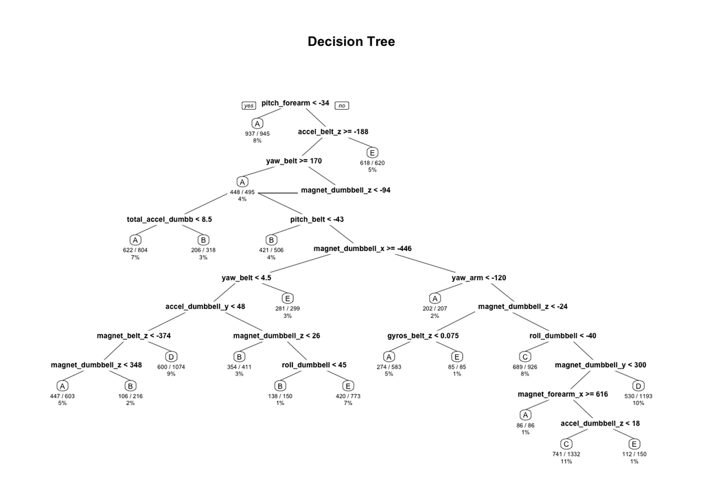

```r
model1 <- rpart(classe ~ ., data = sTraining, method = "class")

#Plot of the Decision Tree
rpart.plot(model1, main="Decision Tree", extra=102, under=TRUE, faclen=0)
```

```r
#Predicting:
prediction1 <- predict(model1, sTesting, type = "class")

#Using confusion matrix to test result
confusionMatrix(prediction1, sTesting$classe)
```

```
## Confusion Matrix and Statistics
##
##           Reference
## Prediction    A    B    C    D    E
##          A 2002  255   59  107   62
##          B   68  785   67   71   51
##          C   35  105  948  255  139
##          D  108  268  258  756  158
##          E   19  105   36   97 1032
##
## Overall Statistics
##
##                Accuracy : 0.7039
##                  95% CI : (0.6937, 0.714)
##     No Information Rate : 0.2845
##     P-Value [Acc > NIR] : < 2.2e-16
##
##                   Kappa : 0.6246
##  Mcnemar's Test P-Value : < 2.2e-16
##
## Statistics by Class:
##
##                      Class: A Class: B Class: C Class: D Class: E
## Sensitivity            0.8970   0.5171   0.6930  0.58787   0.7157
## Specificity            0.9140   0.9594   0.9176  0.87927   0.9599
## Pos Pred Value         0.8056   0.7534   0.6397  0.48837   0.8006
## Neg Pred Value         0.9571   0.8923   0.9340  0.91585   0.9375
## Prevalence             0.2845   0.1935   0.1744  0.16391   0.1838
## Detection Rate         0.2552   0.1001   0.1208  0.09635   0.1315
## Detection Prevalence   0.3167   0.1328   0.1889  0.19730   0.1643
## Balanced Accuracy      0.9055   0.7383   0.8053  0.73357   0.8378
```

### Using Random Forest as the second prediction model

```r
model2 <- randomForest(classe ~. , data=sTraining, method="class")
#Predicting:
prediction2 <- predict(model2, sTesting, type = "class")

#Test results on subTesting data set:
confusionMatrix(prediction2, sTesting$classe)
```

```
## Confusion Matrix and Statistics
##
##           Reference
## Prediction    A    B    C    D    E
##          A 2230    9    0    0    0
##          B    2 1504    6    0    0
##          C    0    5 1362   16    3
##          D    0    0    0 1268    4
##          E    0    0    0    2 1435
##
## Overall Statistics
##
##                Accuracy : 0.994
##                  95% CI : (0.992, 0.9956)
##     No Information Rate : 0.2845
##     P-Value [Acc > NIR] : < 2.2e-16
##
##                   Kappa : 0.9924
##  Mcnemar's Test P-Value : NA
##
## Statistics by Class:
##
##                      Class: A Class: B Class: C Class: D Class: E
## Sensitivity            0.9991   0.9908   0.9956   0.9860   0.9951
## Specificity            0.9984   0.9987   0.9963   0.9994   0.9997
## Pos Pred Value         0.9960   0.9947   0.9827   0.9969   0.9986
## Neg Pred Value         0.9996   0.9978   0.9991   0.9973   0.9989
## Prevalence             0.2845   0.1935   0.1744   0.1639   0.1838
## Detection Rate         0.2842   0.1917   0.1736   0.1616   0.1829
## Detection Prevalence   0.2854   0.1927   0.1767   0.1621   0.1832
## Balanced Accuracy      0.9988   0.9948   0.9960   0.9927   0.9974
```

### Decision

A Random Forest model gives us much more accuracy that a Decision Tree model (0.994 vs 0.7039). Thus choosing the Random Forest model. Our Test data set includes 20 cases. With an accuracy above 99% on our cross-validation data, we can expect that very few, or none, of the test samples will be missclassified.

### Submission

```r
# predict outcome levels on the original Testing data set using Random Forest algorithm
prediction <- predict(model2, testing, type="class")
prediction
```

```
##  1  2  3  4  5  6  7  8  9 10 11 12 13 14 15 16 17 18 19 20
##  B  A  B  A  A  E  D  B  A  A  B  C  B  A  E  E  A  B  B  B
## Levels: A B C D E
```

```r
# Write files for submission
pml_write_files = function(x){
  n = length(x)
  for(i in 1:n){
    filename = paste0("problem_id_",i,".txt")
    write.table(x[i],file=filename,quote=FALSE,row.names=FALSE,col.names=FALSE)
  }
}

pml_write_files(prediction)
```